# Dimensionality Analyses of the Character Judgments

Pooya Razavi

last knitted: 2022-10-08 16:12:12

# Data Preparation

```r
#remove rows that are all NAs
df_na_removed <- df %>%
                    dplyr::filter(!if_all(c(Q20_1, Q70), is.na))

#the original column names (imported from Qualtrics)
dplyr::glimpse(df[,1:20])
```

```
## Rows: 867
## Columns: 20
## $ Duration__in_seconds_ <dbl> 1064, 1485, 332, 953, 943, 1946, 651, 1071, 2193~
## $ RecordedDate          <dttm> 2021-01-01 19:17:22, 2021-01-02 13:36:24, 2021-~
## $ ResponseId            <chr> "R_dhfMnyYywh30uZz", "R_1gIt510YN301lli", "R_2DM~
## $ Q20_1                 <dbl> NA, NA, NA, 2, 4, NA, NA, NA, NA, 4, NA, NA, 3, ~
## $ Q20_2                 <dbl> NA, NA, NA, 3, 4, NA, NA, NA, NA, 4, NA, NA, 4, ~
## $ Q20_3                 <dbl> NA, NA, NA, 4, 3, NA, NA, NA, NA, 3, NA, NA, 3, ~
## $ Q20_4                 <dbl> NA, NA, NA, 3, 4, NA, NA, NA, NA, 3, NA, NA, 3, ~
## $ Q20_5                 <dbl> NA, NA, NA, 2, 4, NA, NA, NA, NA, 3, NA, NA, 3, ~
## $ Q20_6                 <dbl> NA, NA, NA, 4, 4, NA, NA, NA, NA, 3, NA, NA, 3, ~
## $ Q20_7                 <dbl> NA, NA, NA, 3, 4, NA, NA, NA, NA, 2, NA, NA, 3, ~
## $ Q20_8                 <dbl> NA, NA, NA, 2, 2, NA, NA, NA, NA, 3, NA, NA, 3, ~
## $ Q20_9                 <dbl> NA, NA, NA, 5, 2, NA, NA, NA, NA, 3, NA, NA, 3, ~
## $ Q20_10                <dbl> NA, NA, NA, 3, 2, NA, NA, NA, NA, 3, NA, NA, 3, ~
## $ Q20_11                <dbl> NA, NA, NA, 3, 3, NA, NA, NA, NA, 3, NA, NA, 3, ~
## $ Q20_12                <dbl> NA, NA, NA, 2, 2, NA, NA, NA, NA, 1, NA, NA, 2, ~
## $ Q20_13                <dbl> NA, NA, NA, 4, 4, NA, NA, NA, NA, 5, NA, NA, 4, ~
## $ Q20_14                <dbl> NA, NA, NA, 1, 3, NA, NA, NA, NA, 4, NA, NA, 3, ~
## $ Q20_15                <dbl> NA, NA, NA, 5, 3, NA, NA, NA, NA, 3, NA, NA, 3, ~
## $ Q20_16                <dbl> NA, NA, NA, 2, 4, NA, NA, NA, NA, 3, NA, NA, 3, ~
## $ Q20_17                <dbl> NA, NA, NA, 4, 4, NA, NA, NA, NA, 3, NA, NA, 3, ~
```

```r
#use the variable names (from the external file) to rename data columns from Qualtrics labels to the character judgments
colnames(df_na_removed) <- var_name_df$var_name


#now the column names are easier to follow
dplyr::glimpse(df[,1:20])
```

```
## Rows: 867
## Columns: 20
## $ Duration__in_seconds_ <dbl> 1064, 1485, 332, 953, 943, 1946, 651, 1071, 2193~
## $ RecordedDate          <dttm> 2021-01-01 19:17:22, 2021-01-02 13:36:24, 2021-~
## $ ResponseId            <chr> "R_dhfMnyYywh30uZz", "R_1gIt510YN301lli", "R_2DM~
## $ Q20_1                 <dbl> NA, NA, NA, 2, 4, NA, NA, NA, NA, 4, NA, NA, 3, ~
## $ Q20_2                 <dbl> NA, NA, NA, 3, 4, NA, NA, NA, NA, 4, NA, NA, 4, ~
## $ Q20_3                 <dbl> NA, NA, NA, 4, 3, NA, NA, NA, NA, 3, NA, NA, 3, ~
## $ Q20_4                 <dbl> NA, NA, NA, 3, 4, NA, NA, NA, NA, 3, NA, NA, 3, ~
## $ Q20_5                 <dbl> NA, NA, NA, 2, 4, NA, NA, NA, NA, 3, NA, NA, 3, ~
## $ Q20_6                 <dbl> NA, NA, NA, 4, 4, NA, NA, NA, NA, 3, NA, NA, 3, ~
## $ Q20_7                 <dbl> NA, NA, NA, 3, 4, NA, NA, NA, NA, 2, NA, NA, 3, ~
## $ Q20_8                 <dbl> NA, NA, NA, 2, 2, NA, NA, NA, NA, 3, NA, NA, 3, ~
## $ Q20_9                 <dbl> NA, NA, NA, 5, 2, NA, NA, NA, NA, 3, NA, NA, 3, ~
## $ Q20_10                <dbl> NA, NA, NA, 3, 2, NA, NA, NA, NA, 3, NA, NA, 3, ~
## $ Q20_11                <dbl> NA, NA, NA, 3, 3, NA, NA, NA, NA, 3, NA, NA, 3, ~
## $ Q20_12                <dbl> NA, NA, NA, 2, 2, NA, NA, NA, NA, 1, NA, NA, 2, ~
## $ Q20_13                <dbl> NA, NA, NA, 4, 4, NA, NA, NA, NA, 5, NA, NA, 4, ~
## $ Q20_14                <dbl> NA, NA, NA, 1, 3, NA, NA, NA, NA, 4, NA, NA, 3, ~
## $ Q20_15                <dbl> NA, NA, NA, 5, 3, NA, NA, NA, NA, 3, NA, NA, 3, ~
## $ Q20_16                <dbl> NA, NA, NA, 2, 4, NA, NA, NA, NA, 3, NA, NA, 3, ~
## $ Q20_17                <dbl> NA, NA, NA, 4, 4, NA, NA, NA, NA, 3, NA, NA, 3, ~
```

Each participant provided multiple ratings. Before combining all the ratings into a long format, we want to mean-center them, because we don’t want mean differences between the conditions to artificially influence the factor structure. Below, I’ll create a dataframe with mean-centered ratings just for the dimensionality analyses.

```r
ratings_centered <- df_na_removed %>%
                        select(inf_s_m_y_capable.leader:rud_o_f_y_community.work) %>%
                        scale(., scale = FALSE) %>%
                        as_tibble()


#check a couple of columns to show that the mean is indeed zero
mean(ratings_centered$inf_s_m_y_capable.leader, na.rm = TRUE)
```

```
## [1] 1.710205e-16
```

```r
mean(ratings_centered$rud_s_f_n_loyal.truehearted, na.rm = TRUE)
```

```
## [1] 6.709115e-17
```

```r
ratings_centered_longish <- ratings_centered %>%
                              tibble::rowid_to_column() %>%
                              tidyr::pivot_longer(data = .,
                                                  cols = !rowid) %>%
                              separate(name, c("scenario", "harm_target", "prot_gender", "anger_express", "col"),
                                       sep = "_") %>%
                              tidyr::pivot_wider(data = .,
                                                 names_from = col,
                                                 values_from = value)


#remove the row where all ratings are NA
ratings_centered_longish <- ratings_centered_longish %>%
                                  dplyr::filter(!if_all(c(capable.leader, community.work), is.na))
```

# Correlation between Ratings

To avoid bloated specifics, lets find very highly correlated ratings (i.e., r > .65).

```r
ratings_centered_longish %>%
  select(capable.leader:community.work) %>%
  rstatix::cor_mat() %>%
  rstatix::cor_gather(drop.na = TRUE) %>%
  mutate(strong_cor = if_else(cor >= .65, "yes", "no")) %>%
  filter(strong_cor == "yes" & cor < 1)
```

```
## # A tibble: 4 x 5
##   var1           var2             cor     p strong_cor
##   <chr>          <chr>          <dbl> <dbl> <chr>
## 1 brave          capable.leader  0.67     0 yes
## 2 capable.leader brave           0.67     0 yes
## 3 honorable      noble           0.74     0 yes
## 4 noble          honorable       0.74     0 yes
```

“Brave” and “capable of leadership” are highly correlated; so are “honorable” and “noble.” From the first pair, I’ll keep “brave,” and from the second one, I’ll keep “honorable.”

# Determining the Number of Factors

## Scree plot

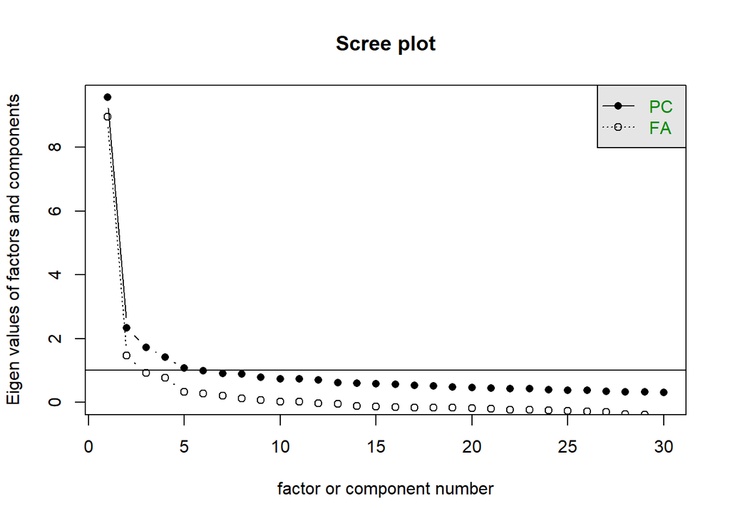

```r
#seems like 4- or 5- factors or components are reasonable solutions
ratings_centered_longish %>%
  select(capable.leader:community.work) %>%
  select(!c(capable.leader, noble)) %>%
  psych::scree()
```

## Parallel analysis

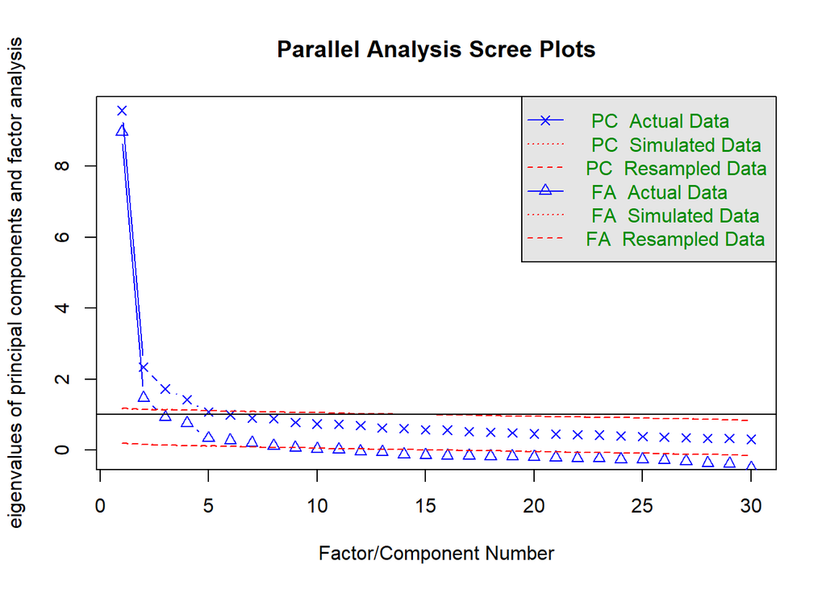

```
## Parallel analysis suggests that the number of factors =  8  and the number of components =  4
```

```r
#Parallel analysis suggests that the number of factors =  8  and the number of components =  4
ratings_centered_longish %>%
  select(capable.leader:community.work) %>%
  select(!c(capable.leader, noble)) %>%
  psych::fa.parallel()
```

## Velicor’s MAP

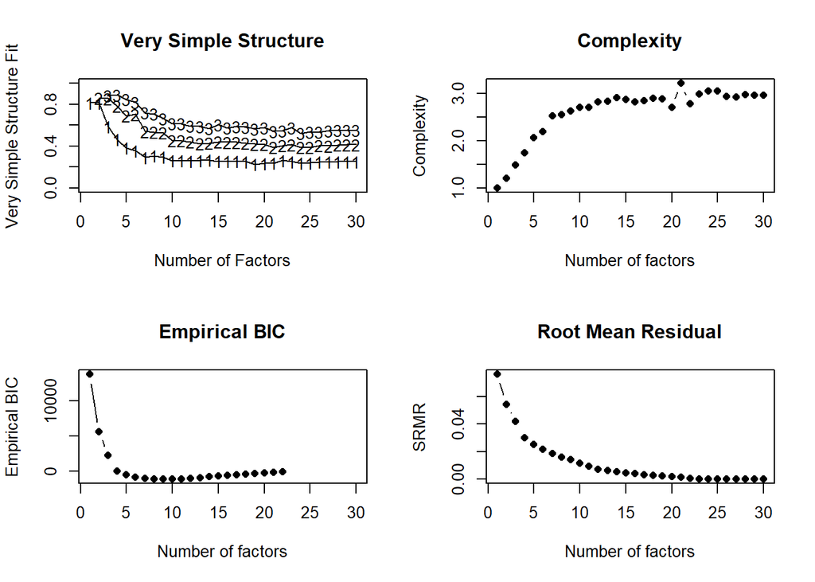

```
##
## Number of factors
## Call: vss(x = x, n = n, rotate = rotate, diagonal = diagonal, fm = fm,
##     n.obs = n.obs, plot = FALSE, title = title, use = use, cor = cor)
## VSS complexity 1 achieves a maximimum of 0.82  with  1  factors
## VSS complexity 2 achieves a maximimum of 0.86  with  2  factors
## The Velicer MAP achieves a minimum of 0.01  with  4  factors
## Empirical BIC achieves a minimum of  -1088.91  with  10  factors
## Sample Size adjusted BIC achieves a minimum of  -336.24  with  13  factors
##
## Statistics by number of factors
##    vss1 vss2    map dof   chisq     prob sqresid  fit  RMSEA  BIC SABIC complex
## 1  0.82 0.00 0.0122 405 1.1e+04  0.0e+00    20.6 0.82 0.0889 8012  9299     1.0
## 2  0.81 0.86 0.0107 376 8.0e+03  0.0e+00    15.6 0.86 0.0772 4946  6140     1.2
## 3  0.59 0.86 0.0100 348 5.9e+03  0.0e+00    13.0 0.88 0.0682 3021  4127     1.5
```

[output cut: 58 more lines]

```r
#The Velicer's MAP suggests a 4-factor structure. Other methods suggest up to 10 components

ratings_centered_longish %>%
  select(capable.leader:community.work) %>%
  select(!c(capable.leader, noble)) %>%
  psych::nfactors(n = 30)
```

# Examining Multiple Structural Solutions

## 2 components

The two-component structure boils down to positive vs. negative characteristics.

```r
pca_2_component <- ratings_centered_longish %>%
                        select(capable.leader:community.work) %>%
                        select(!c(capable.leader, noble)) %>%
                        psych::principal(., nfactors = 2, rotate = "varimax")

two_comp_outcome <- psych::kaiser(pca_2_component, rotate = "Varimax") %>% psych::fa.sort()
two_comp_outcome[["loadings"]] %>%
                  knitr::kable(digits = 2) %>%
                  kableExtra::kable_styling(bootstrap_options = c("striped", "hover")) %>%
                  kableExtra::kable_paper(full_width = F)
```

|  | RC1 | RC2 |
| --- | --- | --- |
| honorable | 0.74 | -0.23 |
| loyal.truehearted | 0.72 | -0.12 |
| helpful.others | 0.71 | -0.16 |
| brave | 0.70 | -0.05 |
| admired | 0.69 | -0.19 |
| respected | 0.67 | -0.27 |
| honest | 0.67 | 0.00 |
| keeps.promises | 0.66 | -0.11 |
| wise | 0.66 | -0.30 |
| values.relations | 0.66 | -0.10 |
| intellectual | 0.66 | -0.31 |
| persistent.steadfast | 0.65 | 0.06 |
| not.compromise.principles | 0.62 | 0.08 |
| grateful | 0.60 | -0.20 |
| virtuous | 0.59 | -0.08 |
| willing.sacrifice | 0.59 | -0.16 |
| not.allow.oppress | 0.57 | 0.19 |
| high.selfesteem | 0.56 | 0.15 |
| has.selfcontrol | 0.50 | -0.45 |
| community.work | 0.50 | -0.17 |
| acts.calculated | 0.46 | -0.26 |
| fits.customs | 0.43 | -0.07 |
| modest | 0.41 | -0.38 |
| religious | 0.23 | 0.06 |
| indifferent | -0.12 | 0.02 |
| holds.grudges | -0.01 | 0.74 |
| stubborn | -0.01 | 0.70 |
| pessimistic.suspicious | -0.08 | 0.68 |
| dogmatic | 0.08 | 0.54 |
| hypocrite | -0.38 | 0.38 |

## 3 components

```r
pca_3_component <- ratings_centered_longish %>%
                        select(capable.leader:community.work) %>%
                        select(!c(capable.leader, noble)) %>%
                        psych::principal(., nfactors = 3, rotate = "varimax")

three_comp_outcome <- psych::kaiser(pca_3_component, rotate = "Varimax") %>% psych::fa.sort()

three_comp_outcome[["loadings"]] %>%
                  knitr::kable(digits = 2) %>%
                  kableExtra::kable_styling(bootstrap_options = c("striped", "hover")) %>%
                  kableExtra::kable_paper(full_width = F)
```

|  | RC1 | RC3 | RC2 |
| --- | --- | --- | --- |
| respected | 0.67 | 0.29 | -0.15 |
| honorable | 0.66 | 0.39 | -0.14 |
| modest | 0.65 | -0.10 | -0.17 |
| admired | 0.64 | 0.33 | -0.09 |
| intellectual | 0.63 | 0.31 | -0.22 |
| grateful | 0.61 | 0.23 | -0.08 |
| helpful.others | 0.61 | 0.39 | -0.08 |
| community.work | 0.61 | 0.07 | 0.00 |
| willing.sacrifice | 0.60 | 0.21 | -0.04 |
| wise | 0.60 | 0.35 | -0.23 |
| has.selfcontrol | 0.58 | 0.15 | -0.34 |
| loyal.truehearted | 0.57 | 0.45 | -0.06 |
| virtuous | 0.56 | 0.25 | 0.03 |
| acts.calculated | 0.53 | 0.13 | -0.14 |
| keeps.promises | 0.49 | 0.45 | -0.07 |
| fits.customs | 0.49 | 0.10 | 0.06 |
| values.relations | 0.48 | 0.46 | -0.07 |
| religious | 0.37 | -0.10 | 0.20 |
| not.allow.oppress | 0.11 | 0.73 | 0.06 |
| high.selfesteem | 0.16 | 0.66 | 0.04 |
| not.compromise.principles | 0.24 | 0.66 | 0.00 |
| honest | 0.33 | 0.64 | -0.05 |
| brave | 0.43 | 0.58 | -0.06 |
| persistent.steadfast | 0.38 | 0.56 | 0.05 |
| indifferent | 0.22 | -0.44 | 0.21 |
| holds.grudges | -0.13 | 0.06 | 0.74 |
| pessimistic.suspicious | -0.10 | -0.09 | 0.73 |
| stubborn | -0.14 | 0.07 | 0.70 |
| dogmatic | 0.05 | 0.00 | 0.60 |
| hypocrite | -0.23 | -0.36 | 0.43 |

## 4 components

We see a clearly interpretable set of components here. Consistent with the scree test and Velicor’s MAP, it seems that the four-component structure is sensible.

```r
pca_4_component <- ratings_centered_longish %>%
                        select(capable.leader:community.work) %>%
                        select(!c(capable.leader, noble)) %>%
                        psych::principal(., nfactors = 4, rotate = "varimax")

four_comp_outcome <- psych::kaiser(pca_4_component, rotate = "Varimax") %>% psych::fa.sort()

four_comp_outcome[["loadings"]] %>%
                  knitr::kable(digits = 2) %>%
                  kableExtra::kable_styling(bootstrap_options = c("striped", "hover")) %>%
                  kableExtra::kable_paper(full_width = F)
```

|  | RC1 | RC3 | RC4 | RC2 |
| --- | --- | --- | --- | --- |
| helpful.others | 0.67 | 0.34 | 0.11 | -0.11 |
| willing.sacrifice | 0.67 | 0.16 | 0.09 | -0.07 |
| community.work | 0.66 | 0.02 | 0.09 | -0.04 |
| admired | 0.64 | 0.30 | 0.21 | -0.11 |
| respected | 0.64 | 0.25 | 0.26 | -0.16 |
| loyal.truehearted | 0.62 | 0.41 | 0.11 | -0.09 |
| grateful | 0.60 | 0.20 | 0.21 | -0.10 |
| honorable | 0.58 | 0.37 | 0.34 | -0.13 |
| keeps.promises | 0.58 | 0.40 | 0.03 | -0.11 |
| virtuous | 0.56 | 0.22 | 0.19 | 0.02 |
| fits.customs | 0.51 | 0.06 | 0.10 | 0.03 |
| values.relations | 0.51 | 0.43 | 0.11 | -0.09 |
| modest | 0.49 | -0.10 | 0.45 | -0.14 |
| religious | 0.36 | -0.11 | 0.12 | 0.20 |
| not.allow.oppress | 0.07 | 0.74 | 0.11 | 0.06 |
| high.selfesteem | 0.10 | 0.68 | 0.16 | 0.05 |
| not.compromise.principles | 0.28 | 0.64 | 0.03 | -0.02 |
| honest | 0.35 | 0.62 | 0.10 | -0.07 |
| brave | 0.29 | 0.59 | 0.38 | -0.03 |
| persistent.steadfast | 0.25 | 0.57 | 0.33 | 0.08 |
| indifferent | 0.02 | -0.41 | 0.35 | 0.27 |
| acts.calculated | 0.18 | 0.18 | 0.71 | -0.05 |
| has.selfcontrol | 0.26 | 0.18 | 0.69 | -0.26 |
| wise | 0.32 | 0.38 | 0.64 | -0.16 |
| intellectual | 0.38 | 0.33 | 0.60 | -0.16 |
| pessimistic.suspicious | -0.07 | -0.08 | -0.11 | 0.73 |
| holds.grudges | -0.04 | 0.06 | -0.22 | 0.72 |
| stubborn | -0.08 | 0.08 | -0.16 | 0.69 |
| dogmatic | 0.01 | 0.03 | 0.06 | 0.61 |
| hypocrite | -0.32 | -0.31 | 0.05 | 0.47 |

```r
pca_4_component_v2 <- ratings_centered_longish %>%
                        select(capable.leader:community.work) %>%
                        select(!c(capable.leader, noble)) %>%
                        select(!c(modest)) %>%
                        psych::principal(., nfactors = 4, rotate = "varimax")

four_comp_outcome_v2 <- psych::kaiser(pca_4_component_v2, rotate = "Varimax") %>% psych::fa.sort()

four_comp_outcome_v2[["loadings"]] %>%
                  knitr::kable(digits = 2) %>%
                  kableExtra::kable_styling(bootstrap_options = c("striped", "hover")) %>%
                  kableExtra::kable_paper(full_width = F)
```

|  | RC1 | RC3 | RC4 | RC2 |
| --- | --- | --- | --- | --- |
| willing.sacrifice | 0.68 | 0.13 | 0.10 | -0.07 |
| helpful.others | 0.68 | 0.31 | 0.13 | -0.11 |
| community.work | 0.67 | -0.01 | 0.10 | -0.04 |
| admired | 0.65 | 0.27 | 0.23 | -0.11 |
| respected | 0.64 | 0.22 | 0.27 | -0.16 |
| loyal.truehearted | 0.62 | 0.39 | 0.13 | -0.09 |
| grateful | 0.61 | 0.17 | 0.22 | -0.10 |
| honorable | 0.58 | 0.35 | 0.35 | -0.13 |
| keeps.promises | 0.58 | 0.41 | 0.04 | -0.11 |
| virtuous | 0.56 | 0.20 | 0.19 | 0.02 |
| values.relations | 0.51 | 0.42 | 0.13 | -0.09 |
| fits.customs | 0.51 | 0.05 | 0.09 | 0.03 |
| religious | 0.36 | -0.13 | 0.11 | 0.20 |
| not.allow.oppress | 0.08 | 0.74 | 0.15 | 0.07 |
| high.selfesteem | 0.10 | 0.67 | 0.20 | 0.06 |
| not.compromise.principles | 0.29 | 0.64 | 0.06 | -0.02 |
| honest | 0.36 | 0.62 | 0.12 | -0.07 |
| brave | 0.30 | 0.55 | 0.42 | -0.03 |
| persistent.steadfast | 0.27 | 0.54 | 0.37 | 0.08 |
| indifferent | 0.02 | -0.43 | 0.33 | 0.26 |
| acts.calculated | 0.19 | 0.12 | 0.73 | -0.05 |
| has.selfcontrol | 0.27 | 0.13 | 0.70 | -0.26 |
| wise | 0.33 | 0.33 | 0.66 | -0.16 |
| intellectual | 0.40 | 0.27 | 0.62 | -0.16 |
| pessimistic.suspicious | -0.07 | -0.07 | -0.12 | 0.73 |
| holds.grudges | -0.03 | 0.07 | -0.21 | 0.72 |
| stubborn | -0.08 | 0.09 | -0.15 | 0.69 |
| dogmatic | 0.02 | 0.01 | 0.07 | 0.61 |
| hypocrite | -0.32 | -0.31 | 0.03 | 0.47 |

```r
pca_4_component_v3 <- ratings_centered_longish %>%
                        select(capable.leader:community.work) %>%
                        select(!c(capable.leader, noble)) %>%
                        select(!c(modest, religious)) %>%
                        psych::principal(., nfactors = 4, rotate = "varimax")

four_comp_outcome_v3 <- psych::kaiser(pca_4_component_v3, rotate = "Varimax") %>% psych::fa.sort()

four_comp_outcome_v3[["loadings"]] %>%
                  knitr::kable(digits = 2) %>%
                  kableExtra::kable_styling(bootstrap_options = c("striped", "hover")) %>%
                  kableExtra::kable_paper(full_width = F)
```

|  | RC1 | RC3 | RC4 | RC2 |
| --- | --- | --- | --- | --- |
| helpful.others | 0.71 | 0.25 | 0.14 | -0.08 |
| willing.sacrifice | 0.70 | 0.08 | 0.11 | -0.05 |
| admired | 0.67 | 0.22 | 0.23 | -0.09 |
| respected | 0.67 | 0.18 | 0.27 | -0.14 |
| community.work | 0.66 | -0.04 | 0.10 | -0.03 |
| loyal.truehearted | 0.66 | 0.35 | 0.13 | -0.07 |
| grateful | 0.61 | 0.14 | 0.22 | -0.09 |
| honorable | 0.61 | 0.30 | 0.35 | -0.12 |
| keeps.promises | 0.60 | 0.37 | 0.05 | -0.10 |
| values.relations | 0.54 | 0.38 | 0.13 | -0.08 |
| virtuous | 0.54 | 0.21 | 0.19 | 0.00 |
| fits.customs | 0.51 | 0.03 | 0.10 | 0.04 |
| not.allow.oppress | 0.10 | 0.75 | 0.15 | 0.06 |
| high.selfesteem | 0.12 | 0.68 | 0.20 | 0.05 |
| not.compromise.principles | 0.31 | 0.64 | 0.06 | -0.02 |
| honest | 0.39 | 0.60 | 0.12 | -0.06 |
| brave | 0.34 | 0.53 | 0.42 | -0.02 |
| persistent.steadfast | 0.29 | 0.52 | 0.37 | 0.08 |
| indifferent | -0.01 | -0.44 | 0.33 | 0.27 |
| acts.calculated | 0.19 | 0.11 | 0.73 | -0.05 |
| has.selfcontrol | 0.28 | 0.11 | 0.70 | -0.25 |
| wise | 0.35 | 0.31 | 0.66 | -0.15 |
| intellectual | 0.41 | 0.25 | 0.62 | -0.15 |
| pessimistic.suspicious | -0.07 | -0.09 | -0.11 | 0.74 |
| holds.grudges | -0.04 | 0.06 | -0.21 | 0.73 |
| stubborn | -0.09 | 0.09 | -0.15 | 0.69 |
| dogmatic | 0.01 | 0.00 | 0.07 | 0.62 |
| hypocrite | -0.36 | -0.28 | 0.03 | 0.46 |

## 5 components

We start to see the potential signs of over-factoring here. The last component consists of only 1 item.

```r
pca_5_component <- ratings_centered_longish %>%
                        select(capable.leader:community.work) %>%
                        select(!c(capable.leader, noble)) %>%
                        psych::principal(., nfactors = 5, rotate = "varimax")

five_comp_outcome <- psych::kaiser(pca_5_component, rotate = "Varimax") %>% psych::fa.sort()

five_comp_outcome[["loadings"]] %>%
                  knitr::kable(digits = 2) %>%
                  kableExtra::kable_styling(bootstrap_options = c("striped", "hover")) %>%
                  kableExtra::kable_paper(full_width = F)
```

|  | RC1 | RC3 | RC4 | RC2 | RC5 |
| --- | --- | --- | --- | --- | --- |
| helpful.others | 0.73 | 0.20 | 0.16 | -0.07 | 0.01 |
| loyal.truehearted | 0.72 | 0.23 | 0.19 | -0.02 | -0.12 |
| willing.sacrifice | 0.67 | 0.07 | 0.11 | -0.05 | 0.12 |
| admired | 0.67 | 0.18 | 0.25 | -0.07 | 0.06 |
| respected | 0.66 | 0.14 | 0.29 | -0.13 | 0.08 |
| keeps.promises | 0.64 | 0.31 | 0.08 | -0.08 | 0.02 |
| honorable | 0.63 | 0.23 | 0.39 | -0.09 | 0.00 |
| values.relations | 0.62 | 0.26 | 0.19 | -0.02 | -0.16 |
| grateful | 0.60 | 0.12 | 0.23 | -0.08 | 0.14 |
| community.work | 0.57 | 0.04 | 0.06 | -0.08 | 0.41 |
| virtuous | 0.49 | 0.25 | 0.16 | -0.03 | 0.37 |
| fits.customs | 0.46 | 0.05 | 0.09 | 0.01 | 0.27 |
| not.allow.oppress | 0.13 | 0.79 | 0.12 | 0.03 | 0.06 |
| high.selfesteem | 0.11 | 0.75 | 0.15 | 0.00 | 0.17 |
| not.compromise.principles | 0.34 | 0.64 | 0.05 | -0.04 | 0.06 |
| honest | 0.46 | 0.53 | 0.15 | -0.04 | -0.09 |
| persistent.steadfast | 0.33 | 0.50 | 0.37 | 0.10 | -0.05 |
| brave | 0.39 | 0.48 | 0.44 | 0.01 | -0.12 |
| indifferent | -0.13 | -0.34 | 0.30 | 0.21 | 0.33 |
| acts.calculated | 0.16 | 0.13 | 0.72 | -0.05 | 0.10 |
| has.selfcontrol | 0.27 | 0.10 | 0.71 | -0.24 | 0.02 |
| wise | 0.36 | 0.28 | 0.68 | -0.13 | -0.02 |
| intellectual | 0.41 | 0.23 | 0.63 | -0.13 | 0.02 |
| modest | 0.41 | -0.14 | 0.43 | -0.16 | 0.27 |
| holds.grudges | -0.01 | 0.02 | -0.19 | 0.76 | -0.09 |
| pessimistic.suspicious | -0.07 | -0.11 | -0.09 | 0.75 | -0.05 |
| stubborn | -0.08 | 0.08 | -0.15 | 0.70 | -0.01 |
| dogmatic | -0.03 | 0.04 | 0.05 | 0.60 | 0.12 |
| hypocrite | -0.42 | -0.21 | 0.00 | 0.42 | 0.17 |
| religious | 0.12 | 0.10 | 0.00 | 0.05 | 0.75 |

## 6 components

We see more indications of potential over-factoring. This time, the fifth component consists of a single item (i.e., “indifferent”), and there’s an increase in the number of cross-loading items.

```r
pca_6_component <- ratings_centered_longish %>%
                        select(capable.leader:community.work) %>%
                        select(!c(capable.leader, noble)) %>%
                        psych::principal(., nfactors = 6, rotate = "varimax")

six_comp_outcome <- psych::kaiser(pca_6_component, rotate = "Varimax") %>% psych::fa.sort()

six_comp_outcome[["loadings"]] %>%
                  knitr::kable(digits = 2) %>%
                  kableExtra::kable_styling(bootstrap_options = c("striped", "hover")) %>%
                  kableExtra::kable_paper(full_width = F)
```

|  | RC1 | RC4 | RC3 | RC2 | RC6 | RC5 |
| --- | --- | --- | --- | --- | --- | --- |
| helpful.others | 0.72 | 0.21 | 0.21 | -0.06 | 0.07 | -0.02 |
| willing.sacrifice | 0.70 | 0.13 | 0.10 | -0.05 | -0.06 | 0.03 |
| admired | 0.67 | 0.29 | 0.19 | -0.07 | 0.01 | 0.01 |
| respected | 0.66 | 0.32 | 0.16 | -0.14 | -0.03 | 0.02 |
| loyal.truehearted | 0.64 | 0.32 | 0.15 | 0.02 | 0.34 | 0.01 |
| community.work | 0.62 | 0.03 | 0.10 | -0.10 | -0.21 | 0.27 |
| keeps.promises | 0.61 | 0.15 | 0.29 | -0.06 | 0.17 | 0.04 |
| honorable | 0.59 | 0.45 | 0.21 | -0.08 | 0.10 | 0.03 |
| grateful | 0.53 | 0.33 | 0.04 | -0.05 | 0.21 | 0.25 |
| values.relations | 0.52 | 0.33 | 0.16 | 0.03 | 0.39 | 0.01 |
| fits.customs | 0.49 | 0.08 | 0.09 | 0.00 | -0.14 | 0.18 |
| hypocrite | -0.41 | -0.05 | -0.21 | 0.40 | -0.20 | 0.17 |
| wise | 0.30 | 0.72 | 0.23 | -0.13 | 0.04 | 0.01 |
| acts.calculated | 0.12 | 0.72 | 0.11 | -0.07 | -0.13 | 0.09 |
| has.selfcontrol | 0.23 | 0.72 | 0.08 | -0.25 | -0.07 | 0.02 |
| intellectual | 0.34 | 0.69 | 0.18 | -0.13 | 0.06 | 0.08 |
| brave | 0.31 | 0.52 | 0.42 | 0.03 | 0.20 | -0.04 |
| persistent.steadfast | 0.25 | 0.47 | 0.43 | 0.12 | 0.21 | 0.06 |
| modest | 0.41 | 0.42 | -0.12 | -0.18 | -0.18 | 0.21 |
| not.allow.oppress | 0.13 | 0.15 | 0.79 | 0.03 | 0.06 | 0.04 |
| high.selfesteem | 0.13 | 0.15 | 0.79 | -0.02 | -0.04 | 0.10 |
| not.compromise.principles | 0.34 | 0.09 | 0.65 | -0.03 | 0.09 | 0.04 |
| honest | 0.43 | 0.22 | 0.51 | -0.02 | 0.18 | -0.07 |
| holds.grudges | -0.05 | -0.13 | -0.02 | 0.78 | 0.11 | 0.00 |
| pessimistic.suspicious | -0.06 | -0.11 | -0.08 | 0.75 | -0.13 | -0.08 |
| stubborn | -0.12 | -0.10 | 0.05 | 0.71 | 0.08 | 0.09 |
| dogmatic | 0.03 | -0.02 | 0.13 | 0.56 | -0.34 | -0.03 |
| indifferent | 0.01 | 0.10 | -0.15 | 0.12 | -0.74 | -0.01 |
| religious | 0.10 | 0.04 | 0.05 | 0.05 | -0.04 | 0.85 |
| virtuous | 0.42 | 0.26 | 0.16 | 0.00 | 0.19 | 0.51 |

## 7 components

Has a couple of components with a single item, and some cross-loading items.

```r
pca_7_component <- ratings_centered_longish %>%
                        select(capable.leader:community.work) %>%
                        select(!c(capable.leader, noble)) %>%
                        psych::principal(., nfactors = 7, rotate = "varimax")

seven_comp_outcome <- psych::kaiser(pca_7_component, rotate = "Varimax") %>% psych::fa.sort()

seven_comp_outcome[["loadings"]] %>%
                  knitr::kable(digits = 2) %>%
                  kableExtra::kable_styling(bootstrap_options = c("striped", "hover")) %>%
                  kableExtra::kable_paper(full_width = F)
```

|  | RC1 | RC4 | RC3 | RC2 | RC7 | RC5 | RC6 |
| --- | --- | --- | --- | --- | --- | --- | --- |
| loyal.truehearted | 0.72 | 0.29 | 0.14 | 0.02 | 0.02 | 0.05 | -0.18 |
| helpful.others | 0.70 | 0.19 | 0.20 | -0.07 | 0.19 | 0.00 | 0.04 |
| willing.sacrifice | 0.67 | 0.11 | 0.10 | -0.08 | 0.18 | 0.06 | 0.18 |
| keeps.promises | 0.64 | 0.13 | 0.28 | -0.07 | 0.09 | 0.07 | -0.04 |
| grateful | 0.61 | 0.30 | 0.03 | -0.07 | -0.06 | 0.30 | -0.03 |
| values.relations | 0.60 | 0.31 | 0.15 | 0.03 | 0.04 | 0.03 | -0.28 |
| honorable | 0.58 | 0.45 | 0.20 | -0.08 | 0.19 | 0.04 | -0.03 |
| admired | 0.56 | 0.30 | 0.19 | -0.07 | 0.42 | 0.00 | -0.02 |
| respected | 0.54 | 0.33 | 0.16 | -0.13 | 0.44 | 0.01 | 0.01 |
| community.work | 0.51 | 0.04 | 0.10 | -0.12 | 0.31 | 0.29 | 0.27 |
| hypocrite | -0.48 | -0.03 | -0.20 | 0.41 | 0.04 | 0.13 | 0.09 |
| acts.calculated | 0.08 | 0.73 | 0.11 | -0.07 | 0.10 | 0.08 | 0.10 |
| has.selfcontrol | 0.19 | 0.73 | 0.08 | -0.25 | 0.13 | 0.01 | 0.05 |
| wise | 0.32 | 0.72 | 0.23 | -0.13 | 0.05 | 0.02 | 0.00 |
| intellectual | 0.36 | 0.68 | 0.17 | -0.13 | 0.05 | 0.09 | -0.01 |
| brave | 0.38 | 0.51 | 0.41 | 0.03 | -0.02 | -0.02 | -0.13 |
| persistent.steadfast | 0.30 | 0.45 | 0.42 | 0.12 | 0.00 | 0.07 | -0.16 |
| modest | 0.32 | 0.43 | -0.13 | -0.18 | 0.24 | 0.21 | 0.18 |
| not.allow.oppress | 0.15 | 0.14 | 0.79 | 0.02 | 0.00 | 0.04 | -0.04 |
| high.selfesteem | 0.10 | 0.16 | 0.79 | -0.02 | 0.12 | 0.09 | 0.02 |
| not.compromise.principles | 0.33 | 0.09 | 0.65 | -0.03 | 0.13 | 0.04 | -0.06 |
| honest | 0.50 | 0.19 | 0.50 | -0.03 | -0.03 | -0.04 | -0.06 |
| holds.grudges | -0.02 | -0.14 | -0.02 | 0.78 | -0.01 | -0.01 | -0.09 |
| pessimistic.suspicious | -0.07 | -0.11 | -0.08 | 0.74 | 0.01 | -0.08 | 0.15 |
| stubborn | -0.10 | -0.10 | 0.05 | 0.72 | -0.03 | 0.08 | -0.07 |
| dogmatic | 0.02 | -0.03 | 0.14 | 0.53 | -0.07 | -0.01 | 0.42 |
| fits.customs | 0.20 | 0.15 | 0.09 | 0.03 | 0.80 | 0.11 | -0.08 |
| religious | 0.02 | 0.05 | 0.05 | 0.05 | 0.14 | 0.84 | 0.02 |
| virtuous | 0.48 | 0.23 | 0.16 | -0.02 | -0.07 | 0.55 | -0.04 |
| indifferent | -0.08 | 0.10 | -0.14 | 0.07 | -0.04 | 0.01 | 0.81 |

## 8 components

Cross-loading items keep increasing.

```r
pca_8_component <- ratings_centered_longish %>%
                        select(capable.leader:community.work) %>%
                        select(!c(capable.leader, noble)) %>%
                        psych::principal(., nfactors = 8, rotate = "varimax")

eight_comp_outcome <- psych::kaiser(pca_8_component, rotate = "Varimax") %>% psych::fa.sort()

eight_comp_outcome[["loadings"]] %>%
                  knitr::kable(digits = 2) %>%
                  kableExtra::kable_styling(bootstrap_options = c("striped", "hover")) %>%
                  kableExtra::kable_paper(full_width = F)
```

|  | RC1 | RC4 | RC3 | RC8 | RC2 | RC7 | RC5 | RC6 |
| --- | --- | --- | --- | --- | --- | --- | --- | --- |
| loyal.truehearted | 0.77 | 0.24 | 0.14 | 0.16 | -0.02 | 0.12 | 0.08 | -0.04 |
| values.relations | 0.70 | 0.25 | 0.15 | 0.03 | 0.00 | 0.16 | 0.07 | -0.11 |
| keeps.promises | 0.55 | 0.13 | 0.28 | 0.33 | -0.08 | 0.11 | 0.07 | -0.02 |
| grateful | 0.54 | 0.29 | 0.03 | 0.29 | -0.08 | -0.04 | 0.30 | -0.01 |
| honest | 0.52 | 0.17 | 0.50 | 0.12 | -0.06 | 0.03 | -0.02 | 0.02 |
| honorable | 0.52 | 0.43 | 0.20 | 0.25 | -0.10 | 0.23 | 0.05 | 0.01 |
| hypocrite | -0.48 | -0.01 | -0.19 | -0.14 | 0.44 | -0.02 | 0.12 | 0.05 |
| acts.calculated | 0.04 | 0.74 | 0.11 | 0.08 | -0.07 | 0.09 | 0.08 | 0.07 |
| wise | 0.27 | 0.73 | 0.22 | 0.16 | -0.13 | 0.05 | 0.02 | -0.02 |
| has.selfcontrol | 0.17 | 0.72 | 0.07 | 0.08 | -0.26 | 0.14 | 0.02 | 0.04 |
| intellectual | 0.31 | 0.69 | 0.16 | 0.19 | -0.13 | 0.05 | 0.09 | -0.02 |
| brave | 0.37 | 0.51 | 0.41 | 0.13 | 0.04 | 0.00 | -0.02 | -0.10 |
| persistent.steadfast | 0.24 | 0.48 | 0.42 | 0.19 | 0.16 | -0.03 | 0.05 | -0.19 |
| modest | 0.25 | 0.41 | -0.12 | 0.17 | -0.22 | 0.28 | 0.23 | 0.20 |
| not.allow.oppress | 0.15 | 0.15 | 0.79 | 0.05 | 0.02 | 0.00 | 0.04 | -0.03 |
| high.selfesteem | 0.04 | 0.18 | 0.79 | 0.11 | -0.02 | 0.09 | 0.08 | -0.01 |
| not.compromise.principles | 0.32 | 0.08 | 0.65 | 0.11 | -0.05 | 0.16 | 0.05 | -0.01 |
| community.work | 0.08 | 0.13 | 0.11 | 0.77 | -0.07 | 0.14 | 0.21 | 0.04 |
| willing.sacrifice | 0.30 | 0.19 | 0.10 | 0.74 | -0.03 | 0.05 | 0.00 | 0.01 |
| helpful.others | 0.46 | 0.24 | 0.21 | 0.57 | -0.05 | 0.14 | -0.03 | -0.04 |
| holds.grudges | 0.00 | -0.14 | -0.01 | -0.03 | 0.80 | -0.01 | -0.01 | -0.02 |
| stubborn | -0.11 | -0.08 | 0.06 | 0.01 | 0.74 | -0.07 | 0.05 | -0.06 |
| pessimistic.suspicious | -0.03 | -0.13 | -0.07 | -0.08 | 0.71 | 0.04 | -0.08 | 0.25 |
| fits.customs | 0.14 | 0.12 | 0.11 | 0.13 | 0.02 | 0.83 | 0.13 | -0.03 |
| respected | 0.38 | 0.34 | 0.16 | 0.37 | -0.13 | 0.44 | 0.00 | -0.01 |
| admired | 0.41 | 0.31 | 0.19 | 0.37 | -0.07 | 0.42 | 0.00 | -0.02 |
| religious | 0.01 | 0.03 | 0.06 | 0.04 | 0.04 | 0.15 | 0.85 | 0.05 |
| virtuous | 0.41 | 0.24 | 0.16 | 0.27 | -0.02 | -0.06 | 0.54 | -0.04 |
| indifferent | -0.18 | 0.09 | -0.14 | 0.10 | -0.01 | -0.05 | 0.02 | 0.81 |
| dogmatic | 0.10 | -0.08 | 0.15 | -0.13 | 0.44 | 0.02 | 0.03 | 0.59 |

## 9 components

9-component structure has multiple cross-loading item; removing them will leave some components with a single item. Potential indications that too many components are extracted.

```r
pca_9_component <- ratings_centered_longish %>%
                        select(capable.leader:community.work) %>%
                        select(!c(capable.leader, noble)) %>%
                        psych::principal(., nfactors = 9, rotate = "varimax")

nine_comp_outcome <- psych::kaiser(pca_9_component, rotate = "Varimax") %>% psych::fa.sort()

nine_comp_outcome[["loadings"]] %>%
                  knitr::kable(digits = 2) %>%
                  kableExtra::kable_styling(bootstrap_options = c("striped", "hover")) %>%
                  kableExtra::kable_paper(full_width = F)
```

|  | RC1 | RC4 | RC3 | RC8 | RC2 | RC7 | RC5 | RC6 | RC9 |
| --- | --- | --- | --- | --- | --- | --- | --- | --- | --- |
| loyal.truehearted | 0.76 | 0.24 | 0.15 | 0.15 | -0.05 | 0.13 | 0.04 | -0.08 | 0.05 |
| values.relations | 0.67 | 0.27 | 0.13 | 0.06 | -0.06 | 0.16 | 0.06 | -0.21 | 0.11 |
| grateful | 0.62 | 0.26 | 0.08 | 0.23 | -0.01 | -0.02 | 0.24 | 0.14 | -0.21 |
| keeps.promises | 0.59 | 0.10 | 0.32 | 0.28 | -0.05 | 0.13 | 0.01 | 0.07 | -0.13 |
| honest | 0.52 | 0.17 | 0.52 | 0.10 | -0.07 | 0.04 | -0.05 | 0.01 | 0.01 |
| honorable | 0.52 | 0.43 | 0.20 | 0.24 | -0.11 | 0.24 | 0.03 | 0.02 | 0.00 |
| acts.calculated | 0.05 | 0.74 | 0.10 | 0.07 | -0.05 | 0.09 | 0.08 | 0.11 | -0.03 |
| wise | 0.26 | 0.73 | 0.21 | 0.16 | -0.13 | 0.06 | 0.02 | 0.00 | -0.03 |
| has.selfcontrol | 0.17 | 0.72 | 0.06 | 0.08 | -0.26 | 0.15 | 0.02 | 0.07 | -0.04 |
| intellectual | 0.31 | 0.69 | 0.15 | 0.19 | -0.13 | 0.06 | 0.08 | 0.00 | -0.04 |
| brave | 0.33 | 0.54 | 0.38 | 0.16 | -0.01 | -0.01 | -0.01 | -0.18 | 0.08 |
| persistent.steadfast | 0.23 | 0.51 | 0.39 | 0.21 | 0.13 | -0.03 | 0.06 | -0.22 | 0.01 |
| high.selfesteem | 0.05 | 0.18 | 0.80 | 0.09 | 0.01 | 0.09 | 0.07 | 0.02 | -0.06 |
| not.allow.oppress | 0.13 | 0.17 | 0.78 | 0.06 | 0.01 | -0.01 | 0.04 | -0.08 | 0.06 |
| not.compromise.principles | 0.30 | 0.09 | 0.65 | 0.11 | -0.07 | 0.16 | 0.04 | -0.06 | 0.05 |
| community.work | 0.09 | 0.13 | 0.10 | 0.78 | -0.07 | 0.14 | 0.22 | 0.07 | -0.04 |
| willing.sacrifice | 0.28 | 0.20 | 0.09 | 0.75 | -0.06 | 0.04 | 0.01 | -0.01 | 0.02 |
| helpful.others | 0.45 | 0.24 | 0.20 | 0.58 | -0.07 | 0.14 | -0.04 | -0.05 | 0.00 |
| holds.grudges | 0.02 | -0.14 | -0.01 | -0.03 | 0.79 | -0.01 | -0.03 | -0.07 | 0.14 |
| stubborn | -0.05 | -0.10 | 0.08 | -0.03 | 0.78 | -0.06 | 0.03 | -0.01 | -0.01 |
| pessimistic.suspicious | -0.05 | -0.11 | -0.09 | -0.05 | 0.64 | 0.03 | -0.06 | 0.07 | 0.41 |
| hypocrite | -0.41 | -0.04 | -0.16 | -0.19 | 0.51 | -0.01 | 0.10 | 0.17 | -0.10 |
| fits.customs | 0.14 | 0.11 | 0.11 | 0.12 | 0.02 | 0.84 | 0.12 | -0.01 | -0.01 |
| respected | 0.38 | 0.34 | 0.16 | 0.37 | -0.14 | 0.44 | -0.01 | 0.00 | -0.02 |
| admired | 0.39 | 0.31 | 0.18 | 0.39 | -0.10 | 0.42 | -0.01 | -0.05 | 0.03 |
| religious | 0.02 | 0.04 | 0.03 | 0.06 | 0.00 | 0.14 | 0.88 | -0.01 | 0.10 |
| virtuous | 0.45 | 0.23 | 0.17 | 0.25 | 0.00 | -0.06 | 0.52 | 0.01 | -0.08 |
| indifferent | -0.11 | 0.03 | -0.08 | 0.03 | 0.04 | -0.04 | -0.02 | 0.87 | 0.18 |
| modest | 0.34 | 0.35 | -0.07 | 0.10 | -0.14 | 0.30 | 0.17 | 0.39 | -0.19 |
| dogmatic | -0.01 | -0.02 | 0.06 | -0.01 | 0.24 | -0.02 | 0.10 | 0.15 | 0.84 |

## 10 components

10-component structure has at least 3 single-item components, and multiple cross-loading items; removing the cross-loading items will leave even more components with a single item. Potential indications that too many components are extracted.

```r
pca_10_component <- ratings_centered_longish %>%
                        select(capable.leader:community.work) %>%
                        select(!c(capable.leader, noble)) %>%
                        psych::principal(., nfactors = 10, rotate = "varimax")

ten_comp_outcome <- psych::kaiser(pca_10_component, rotate = "Varimax") %>% psych::fa.sort()

ten_comp_outcome[["loadings"]] %>%
                  knitr::kable(digits = 2) %>%
                  kableExtra::kable_styling(bootstrap_options = c("striped", "hover")) %>%
                  kableExtra::kable_paper(full_width = F)
```

|  | RC4 | RC1 | RC3 | RC8 | RC2 | RC10 | RC7 | RC5 | RC6 | RC9 |
| --- | --- | --- | --- | --- | --- | --- | --- | --- | --- | --- |
| acts.calculated | 0.79 | 0.00 | 0.09 | 0.07 | 0.00 | 0.12 | 0.04 | 0.11 | 0.07 | -0.04 |
| has.selfcontrol | 0.74 | 0.16 | 0.07 | 0.09 | -0.23 | 0.08 | 0.12 | 0.02 | 0.04 | -0.03 |
| wise | 0.70 | 0.30 | 0.25 | 0.18 | -0.14 | 0.03 | 0.06 | -0.01 | -0.01 | -0.01 |
| intellectual | 0.69 | 0.29 | 0.17 | 0.20 | -0.11 | 0.12 | 0.04 | 0.07 | -0.02 | -0.04 |
| brave | 0.45 | 0.42 | 0.44 | 0.19 | -0.05 | -0.03 | 0.03 | -0.07 | -0.16 | 0.11 |
| honorable | 0.44 | 0.44 | 0.18 | 0.26 | -0.07 | 0.29 | 0.23 | 0.03 | 0.01 | -0.01 |
| modest | 0.38 | 0.29 | -0.08 | 0.11 | -0.12 | 0.13 | 0.29 | 0.17 | 0.38 | -0.20 |
| loyal.truehearted | 0.20 | 0.73 | 0.15 | 0.18 | -0.04 | 0.27 | 0.17 | 0.00 | -0.05 | 0.04 |
| values.relations | 0.20 | 0.70 | 0.16 | 0.09 | -0.09 | 0.14 | 0.21 | 0.00 | -0.18 | 0.12 |
| grateful | 0.20 | 0.66 | 0.11 | 0.26 | -0.05 | 0.06 | 0.02 | 0.17 | 0.17 | -0.20 |
| virtuous | 0.18 | 0.50 | 0.19 | 0.27 | -0.02 | 0.05 | -0.04 | 0.48 | 0.03 | -0.07 |
| high.selfesteem | 0.14 | 0.05 | 0.81 | 0.09 | 0.00 | 0.08 | 0.11 | 0.06 | 0.04 | -0.06 |
| not.allow.oppress | 0.10 | 0.15 | 0.80 | 0.07 | -0.02 | 0.06 | 0.02 | 0.01 | -0.06 | 0.07 |
| not.compromise.principles | 0.13 | 0.13 | 0.58 | 0.10 | 0.02 | 0.46 | 0.14 | 0.09 | -0.07 | 0.02 |
| persistent.steadfast | 0.40 | 0.35 | 0.47 | 0.23 | 0.07 | -0.15 | 0.01 | -0.01 | -0.20 | 0.04 |
| community.work | 0.13 | 0.06 | 0.10 | 0.78 | -0.07 | 0.05 | 0.13 | 0.22 | 0.07 | -0.04 |
| willing.sacrifice | 0.18 | 0.25 | 0.09 | 0.76 | -0.05 | 0.11 | 0.05 | -0.01 | 0.00 | 0.02 |
| helpful.others | 0.22 | 0.39 | 0.20 | 0.59 | -0.05 | 0.22 | 0.15 | -0.06 | -0.04 | -0.01 |
| holds.grudges | -0.12 | -0.02 | -0.03 | -0.04 | 0.82 | 0.02 | -0.02 | 0.00 | -0.07 | 0.12 |
| stubborn | -0.09 | -0.07 | 0.07 | -0.04 | 0.80 | -0.06 | -0.07 | 0.05 | -0.01 | -0.02 |
| pessimistic.suspicious | -0.13 | -0.02 | -0.08 | -0.05 | 0.62 | -0.14 | 0.04 | -0.07 | 0.08 | 0.41 |
| hypocrite | -0.13 | -0.16 | -0.06 | -0.18 | 0.37 | -0.63 | 0.04 | 0.02 | 0.20 | -0.05 |
| keeps.promises | 0.16 | 0.39 | 0.24 | 0.28 | 0.05 | 0.51 | 0.10 | 0.06 | 0.07 | -0.17 |
| honest | 0.20 | 0.37 | 0.46 | 0.10 | 0.01 | 0.47 | 0.03 | -0.03 | 0.01 | -0.02 |
| fits.customs | 0.09 | 0.15 | 0.13 | 0.14 | -0.02 | -0.02 | 0.86 | 0.10 | 0.00 | 0.00 |
| respected | 0.37 | 0.27 | 0.13 | 0.38 | -0.10 | 0.28 | 0.43 | 0.01 | -0.01 | -0.04 |
| admired | 0.34 | 0.28 | 0.15 | 0.39 | -0.04 | 0.30 | 0.40 | 0.01 | -0.05 | 0.02 |
| religious | 0.07 | 0.04 | 0.02 | 0.07 | 0.02 | 0.00 | 0.11 | 0.89 | -0.02 | 0.10 |
| indifferent | 0.04 | -0.08 | -0.07 | 0.03 | 0.00 | -0.12 | -0.03 | -0.03 | 0.87 | 0.19 |
| dogmatic | -0.04 | -0.01 | 0.06 | -0.01 | 0.24 | 0.02 | -0.02 | 0.10 | 0.15 | 0.84 |

# Optimal Structure

Considering these results, it seems that the following 4-component structure is the most interpretable, and fewer issues in terms of number of items per dimension and cross-loading items.

## Loadings

```r
four_comp_outcome_v3[["loadings"]] %>%
                  knitr::kable(digits = 2) %>%
                  kableExtra::kable_styling(bootstrap_options = c("striped", "hover")) %>%
                  kableExtra::kable_paper(full_width = F)
```

|  | RC1 | RC3 | RC4 | RC2 |
| --- | --- | --- | --- | --- |
| helpful.others | 0.71 | 0.25 | 0.14 | -0.08 |
| willing.sacrifice | 0.70 | 0.08 | 0.11 | -0.05 |
| admired | 0.67 | 0.22 | 0.23 | -0.09 |
| respected | 0.67 | 0.18 | 0.27 | -0.14 |
| community.work | 0.66 | -0.04 | 0.10 | -0.03 |
| loyal.truehearted | 0.66 | 0.35 | 0.13 | -0.07 |
| grateful | 0.61 | 0.14 | 0.22 | -0.09 |
| honorable | 0.61 | 0.30 | 0.35 | -0.12 |
| keeps.promises | 0.60 | 0.37 | 0.05 | -0.10 |
| values.relations | 0.54 | 0.38 | 0.13 | -0.08 |
| virtuous | 0.54 | 0.21 | 0.19 | 0.00 |
| fits.customs | 0.51 | 0.03 | 0.10 | 0.04 |
| not.allow.oppress | 0.10 | 0.75 | 0.15 | 0.06 |
| high.selfesteem | 0.12 | 0.68 | 0.20 | 0.05 |
| not.compromise.principles | 0.31 | 0.64 | 0.06 | -0.02 |
| honest | 0.39 | 0.60 | 0.12 | -0.06 |
| brave | 0.34 | 0.53 | 0.42 | -0.02 |
| persistent.steadfast | 0.29 | 0.52 | 0.37 | 0.08 |
| indifferent | -0.01 | -0.44 | 0.33 | 0.27 |
| acts.calculated | 0.19 | 0.11 | 0.73 | -0.05 |
| has.selfcontrol | 0.28 | 0.11 | 0.70 | -0.25 |
| wise | 0.35 | 0.31 | 0.66 | -0.15 |
| intellectual | 0.41 | 0.25 | 0.62 | -0.15 |
| pessimistic.suspicious | -0.07 | -0.09 | -0.11 | 0.74 |
| holds.grudges | -0.04 | 0.06 | -0.21 | 0.73 |
| stubborn | -0.09 | 0.09 | -0.15 | 0.69 |
| dogmatic | 0.01 | 0.00 | 0.07 | 0.62 |
| hypocrite | -0.36 | -0.28 | 0.03 | 0.46 |

## Visualization

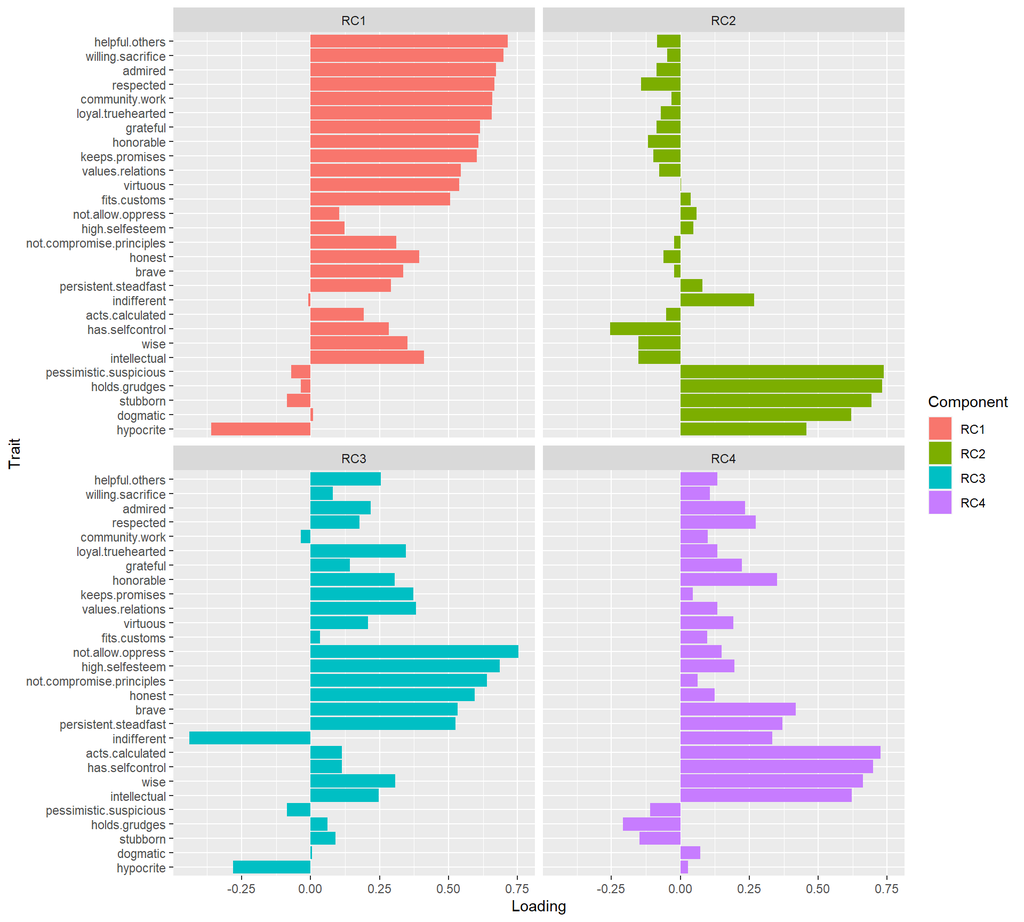

```r
four_comp_df <- four_comp_outcome_v3[["loadings"]] %>%
            as.data.frame() %>%
            tibble::rownames_to_column(., "Trait")

four_comp_df$Trait <- factor(four_comp_df$Trait, levels = four_comp_df$Trait) #this is needed to that ggplot doesn't rearrange the order of rating items alphabetically

four_comp_df_long <- four_comp_df %>%
                          tidyr::pivot_longer(data = .,
                                cols = starts_with("RC"),
                                names_to = "Component",
                                values_to = "Loading")

four_comp_df_long %>%
  ggplot(aes(x = Trait, y = Loading, fill = Component)) +
        geom_bar(stat = "identity") +
        scale_x_discrete(limits = rev(levels(four_comp_df$Trait))) +#reverse the order of the item labels
        facet_wrap(~Component) +
        coord_flip()
```

```r
#in case you want to try a different method where each component is graphed separately
comp1_fig <- four_comp_df %>%
                ggplot(aes(x = Trait, y = RC1)) +
                geom_bar(stat = "identity") +
                scale_x_discrete(limits = rev(levels(four_comp_df$Trait))) + #reverse the order of the item labels
                coord_flip()
```

## Scoring and reliability

```r
ratings_longish <- df_na_removed %>%
                              #tibble::rowid_to_column() %>%
                              tidyr::pivot_longer(data = .,
                                                  cols = inf_s_m_y_capable.leader:rud_o_f_y_community.work) %>%
                              separate(name, c("scenario", "harm_target", "prot_gender", "anger_express", "col"),
                                       sep = "_") %>%
                              tidyr::pivot_wider(data = .,
                                                 names_from = col,
                                                 values_from = value)


#remove the row where all ratings are NA
ratings_longish <- ratings_longish %>%
                                  dplyr::filter(!if_all(c(capable.leader, community.work), is.na))



ratings_key <- list(
  social_conscience = c("helpful.others", "willing.sacrifice", "admired", "respected", "community.work",
                        "loyal.truehearted", "grateful", "honorable", "keeps.promises", "values.relations",
                        "virtuous", "fits.customs"),
  steadfastness = c("not.allow.oppress", "high.selfesteem", "not.compromise.principles", "honest", "brave",
                    "persistent.steadfast", "-indifferent"),
  wisdom = c("acts.calculated", "has.selfcontrol", "wise", "intellectual"),
  obstinacy = c("pessimistic.suspicious", "holds.grudges", "stubborn", "dogmatic", "hypocrite")
)

#calculate scale scores
      judgment.categories <- psych::scoreItems(ratings_key, ratings_longish, impute = "none")
#internal consistencies and intercorrelations
      judgment.categories
```

```
## Call: psych::scoreItems(keys = ratings_key, items = ratings_longish,
##     impute = "none")
##
## (Standardized) Alpha:
##       social_conscience steadfastness wisdom obstinacy
## alpha               0.9           0.8   0.85      0.76
##
## Standard errors of unstandardized Alpha:
##       social_conscience steadfastness wisdom obstinacy
## ASE              0.0046        0.0088  0.011     0.012
##
## Standardized Alpha of observed scales:
##      social_conscience steadfastness wisdom obstinacy
## [1,]               0.9           0.8   0.85      0.75
##
## Average item correlation:
##           social_conscience steadfastness wisdom obstinacy
## average.r              0.43          0.36   0.59      0.38
##
## Median item correlation:
## social_conscience     steadfastness            wisdom         obstinacy
##              0.44              0.40              0.61              0.33
##
##  Guttman 6* reliability:
##          social_conscience steadfastness wisdom obstinacy
## Lambda.6              0.91          0.82   0.84      0.76
##
## Signal/Noise based upon av.r :
##              social_conscience steadfastness wisdom obstinacy
## Signal/Noise               9.2             4    5.7       3.1
##
## Scale intercorrelations corrected for attenuation
##  raw correlations below the diagonal, alpha on the diagonal
##  corrected correlations above the diagonal:
##
## Note that these are the correlations of the complete scales based on the correlation matrix,
##  not the observed scales based on the raw items.
##                   social_conscience steadfastness wisdom obstinacy
## social_conscience              0.90         0.652   0.72    -0.404
## steadfastness                  0.55         0.800   0.41    -0.076
## wisdom                         0.63         0.337   0.85    -0.593
## obstinacy                     -0.33        -0.059  -0.48     0.755
##
##  In order to see the item by scale loadings and frequency counts of the data
##  print with the short option = FALSE
```

```r
ratings_longish <- cbind(ratings_longish, judgment.categories$scores)
```